# Personal Activity Monitoring

Kushal M Kulkarni

18/07/2020

# 1. Load and preprocessing the data

**Fix knitr settings**

```r
knitr::opts_chunk$set(echo = TRUE, fig.width = 12, fig.height = 6, warning = FALSE)
```

**Reading the Data**

```r
activity <- read.csv("activity.csv")
```

**Loading tidyverse package**

```r
library(tidyverse)
```

**View the data**

```r
tibble(activity)
```

```
## # A tibble: 17,568 x 3
##    steps date       interval
##    <int> <chr>         <int>
##  1    NA 2012-10-01        0
##  2    NA 2012-10-01        5
##  3    NA 2012-10-01       10
##  4    NA 2012-10-01       15
##  5    NA 2012-10-01       20
##  6    NA 2012-10-01       25
##  7    NA 2012-10-01       30
##  8    NA 2012-10-01       35
##  9    NA 2012-10-01       40
## 10    NA 2012-10-01       45
## # ... with 17,558 more rows
```

**Convert date column from char to date class**

```r
activity$date <- as.Date(activity$date)
```

# 2. Mean total number of steps taken per day

### 2.1 Histogram

(NAs not removed)

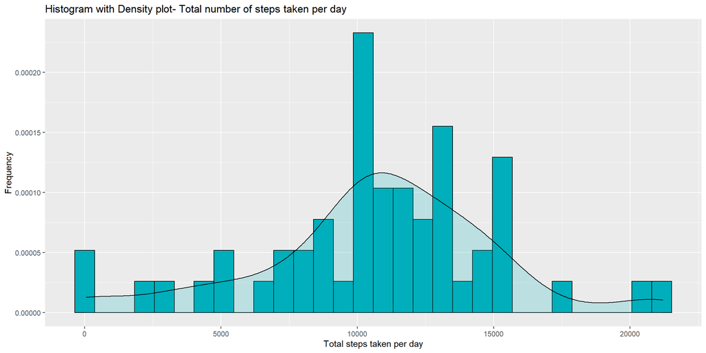

```r
eachday <- activity %>% group_by(date) %>% summarise(TotalSteps = sum(steps))

ggplot(eachday, aes(x = TotalSteps)) +
        geom_histogram(aes(y=..density..), bins = 30, color="black", fill="#00AFBB") +
        geom_density(alpha=.2, fill="#00AFBB") +
        ggtitle("Histogram with Density plot- Total number of steps taken per day") +
        ylab("Frequency") +
        xlab("Total steps taken per day")
```

### 2.2 Mean and Median of total number of steps taken per day

```r
data.frame("Mean" = mean(eachday$TotalSteps, na.rm = T),
           "Median" = median(eachday$TotalSteps, na.rm = T))
```

```
##       Mean Median
## 1 10766.19  10765
```

# 3. The average daily activity pattern

### 3.1 Time Series plot

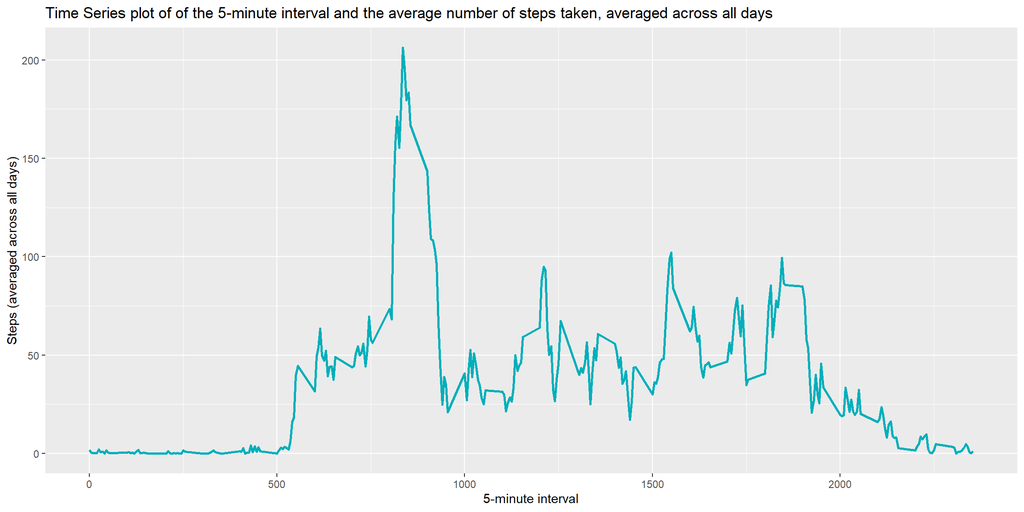

```r
averagesteps <- activity %>%
        group_by(interval) %>%
        summarise(AverageSteps = mean(steps, na.rm = T))
ggplot(averagesteps, aes(x = interval, y = AverageSteps)) +
        geom_line(colour = "#00AFBB", size = 1) +
        ggtitle("Time Series plot of of the 5-minute interval and the average number of steps taken, averaged across all days") +
        xlab("5-minute interval") +
        ylab("Steps (averaged across all days)")
```

### 3.2 Which 5-minute interval, on average across all the days in the dataset, contains the maximum number of steps?

```r
filter(averagesteps, AverageSteps == max(AverageSteps))
```

```
## # A tibble: 1 x 2
##   interval AverageSteps
##      <int>        <dbl>
## 1      835         206.
```

# 4. Imputing missing values

### 4.1 Calculate the Missing Values

**Total missing values in the data are** 2304, **which is** 13% **of the data**

### 4.2 Strategy

- Group the data by **“intervals”** and calculate average **“steps”** taken
- Replace the missing values with **rounded mean** values of steps of 5 minutes interval
- Name this new data set

### 4.3 Create a New Complete Dataset (NAs removed)

**New dataset that is equal to the original dataset but with the missing data filled in.**

```r
CompleteActivity <- activity %>%
        group_by(interval) %>%
        mutate(Rounded.Avg.Steps.forNA = round(mean(steps, na.rm = T))) %>%
        ungroup() %>%
        mutate(steps = ifelse(is.na(steps), Rounded.Avg.Steps.forNA, steps)) %>%
        select(-(Rounded.Avg.Steps.forNA))
```

**New complete dataset**

```r
tibble(CompleteActivity)
```

```
## # A tibble: 17,568 x 3
##    steps date       interval
##    <dbl> <date>        <int>
##  1     2 2012-10-01        0
##  2     0 2012-10-01        5
##  3     0 2012-10-01       10
##  4     0 2012-10-01       15
##  5     0 2012-10-01       20
##  6     2 2012-10-01       25
##  7     1 2012-10-01       30
##  8     1 2012-10-01       35
##  9     0 2012-10-01       40
## 10     1 2012-10-01       45
## # ... with 17,558 more rows
```

### 4.4 Histogram - total number of steps taken per day NAs replaced

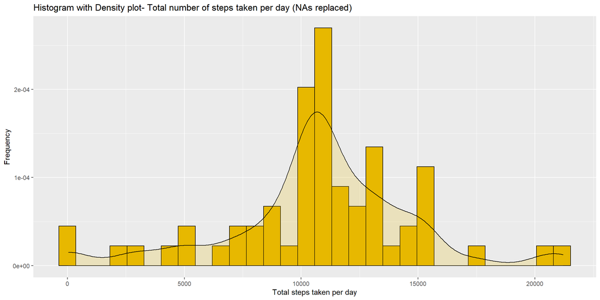

[figure not shown]

```r
Neweachday <- CompleteActivity %>% group_by(date) %>% summarise(TotalSteps = sum(steps))
ggplot(Neweachday, aes(x = TotalSteps)) +
        geom_histogram(aes(y=..density..), bins = 30, color="black", fill="#E7B800") +
        geom_density(alpha=.2, fill="#E7B800") +
        ggtitle("Histogram with Density plot- Total number of steps taken per day (NAs replaced)") +
        ylab("Frequency") +
        xlab("Total steps taken per day")
```

### 4.5 Comparing mean & median values before & after imputing missing values

```r
data.frame("Mean with NAs" = mean(eachday$TotalSteps, na.rm = T),
           "Mean without NAs" = mean(Neweachday$TotalSteps, na.rm = T),
           "Median with NAs" = median(eachday$TotalSteps, na.rm = T),
           "Median without NAs" = median(Neweachday$TotalSteps, na.rm = T))
```

```
##   Mean.with.NAs Mean.without.NAs Median.with.NAs Median.without.NAs
## 1      10766.19         10765.64           10765              10762
```

# 5. Are there differences in activity patterns between weekdays and weekends?

### 5.1 Group (factor) the data by Weekdays and Weekends using weekdays() function

```r
Week.days.ends <- CompleteActivity %>%
        group_by(date) %>%
        mutate(DayType = ifelse(weekdays(date) == c("Sunday", "Saturday"), "Weekend", "Weekday")) %>%
        ungroup() %>%
        group_by(interval, DayType) %>%
        summarise(AverageSTEPS = mean(steps))
```

**New factored dataset (weekday & weekend)**

```r
tibble(Week.days.ends)
```

```
## # A tibble: 576 x 3
##    interval DayType AverageSTEPS
##       <int> <chr>          <dbl>
##  1        0 Weekday       1.98
##  2        0 Weekend       0.25
##  3        5 Weekday       0.340
##  4        5 Weekend       0
##  5       10 Weekday       0.132
##  6       10 Weekend       0
##  7       15 Weekday       0.151
##  8       15 Weekend       0
##  9       20 Weekday       0.0755
## 10       20 Weekend       0
## # ... with 566 more rows
```

### 5.2 Panel plot containing a time series plot of the 5-minute interval and the average number of steps taken, averaged across all weekdays or weekends.

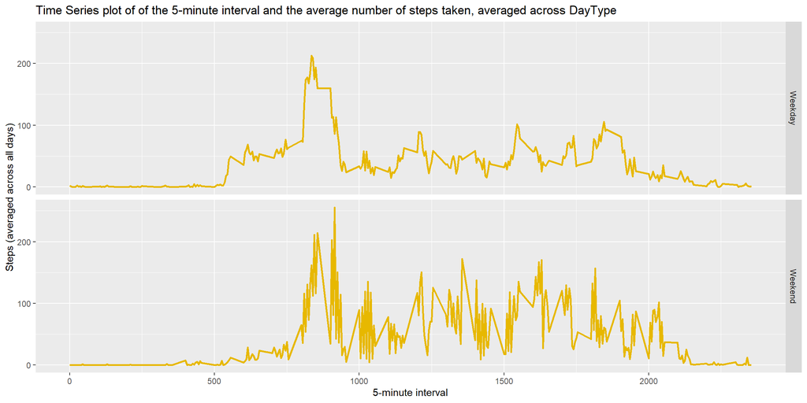

```r
ggplot(Week.days.ends, aes(x = interval, y = AverageSTEPS)) +
        facet_grid(DayType~.) +
        geom_line(colour = "#E7B800", size = 1) +
        ggtitle("Time Series plot of of the 5-minute interval and the average number of steps taken, averaged across DayType") +
        xlab("5-minute interval") +
        ylab("Steps (averaged across all days)")
```

**THANK YOU!**